# Saratoga Houses

Dimitris Athanasakoglou

July 21, 2017

```r
load.libraries <- c('corrplot', 'ggplot2', 'dplyr', 'psych')
install.lib <- load.libraries[!load.libraries %in% installed.packages()]
for(libs in install.lib) install.packages(libs, dependencies = TRUE)
sapply(load.libraries, require, character = TRUE)
```

```
## corrplot  ggplot2    dplyr    psych
##     TRUE     TRUE     TRUE     TRUE
```

## Structure of the Data

The housing dataset has 1728 rows and 16 variables with price being the DV. There are no missing values in the data.

```r
dim(saratoga)
```

```
## [1] 1728   16
```

```r
str(saratoga)
```

```
## 'data.frame':    1728 obs. of  16 variables:
##  $ price          : int  132500 181115 109000 155000 86060 120000 153000 170000 90000 122900 ...
##  $ lotSize        : num  0.09 0.92 0.19 0.41 0.11 0.68 0.4 1.21 0.83 1.94 ...
##  $ age            : int  42 0 133 13 0 31 33 23 36 4 ...
##  $ landValue      : int  50000 22300 7300 18700 15000 14000 23300 14600 22200 21200 ...
##  $ livingArea     : int  906 1953 1944 1944 840 1152 2752 1662 1632 1416 ...
##  $ pctCollege     : int  35 51 51 51 51 22 51 35 51 44 ...
##  $ bedrooms       : int  2 3 4 3 2 4 4 4 3 3 ...
##  $ fireplaces     : int  1 0 1 1 0 1 1 1 0 0 ...
##  $ bathrooms      : num  1 2.5 1 1.5 1 1 1.5 1.5 1.5 1.5 ...
##  $ rooms          : int  5 6 8 5 3 8 8 9 8 6 ...
##  $ heating        : Factor w/ 3 levels "electric","hot air",..: 1 3 3 2 2 2 3 2 1 2 ...
##  $ fuel           : Factor w/ 3 levels "electric","gas",..: 1 2 2 2 2 2 3 3 1 2 ...
##  $ sewer          : Factor w/ 3 levels "none","public/commercial",..: 3 3 2 3 2 3 3 3 3 1 ...
##  $ waterfront     : Factor w/ 2 levels "No","Yes": 1 1 1 1 1 1 1 1 1 1 ...
##  $ newConstruction: Factor w/ 2 levels "No","Yes": 1 1 1 1 2 1 1 1 1 1 ...
##  $ centralAir     : Factor w/ 2 levels "No","Yes": 1 1 1 1 2 1 1 1 1 1 ...
```

```r
sum(is.na(saratoga))
```

```
## [1] 0
```

## Data Issues

The variable bathrooms has numeric value, with half bathrooms indicating bathrooms without bathtubs.

```r
is.numeric(saratoga$bathrooms)
```

```
## [1] TRUE
```

## Descriptive Statistics

```r
summary(saratoga)
```

```
##      price           lotSize             age           landValue
##  Min.   :  5000   Min.   : 0.0000   Min.   :  0.00   Min.   :   200
##  1st Qu.:145000   1st Qu.: 0.1700   1st Qu.: 13.00   1st Qu.: 15100
##  Median :189900   Median : 0.3700   Median : 19.00   Median : 25000
##  Mean   :211967   Mean   : 0.5002   Mean   : 27.92   Mean   : 34557
##  3rd Qu.:259000   3rd Qu.: 0.5400   3rd Qu.: 34.00   3rd Qu.: 40200
##  Max.   :775000   Max.   :12.2000   Max.   :225.00   Max.   :412600
##    livingArea     pctCollege       bedrooms       fireplaces
##  Min.   : 616   Min.   :20.00   Min.   :1.000   Min.   :0.0000
##  1st Qu.:1300   1st Qu.:52.00   1st Qu.:3.000   1st Qu.:0.0000
##  Median :1634   Median :57.00   Median :3.000   Median :1.0000
##  Mean   :1755   Mean   :55.57   Mean   :3.155   Mean   :0.6019
##  3rd Qu.:2138   3rd Qu.:64.00   3rd Qu.:4.000   3rd Qu.:1.0000
##  Max.   :5228   Max.   :82.00   Max.   :7.000   Max.   :4.0000
##    bathrooms       rooms                   heating           fuel
##  Min.   :0.0   Min.   : 2.000   electric       : 305   electric: 315
##  1st Qu.:1.5   1st Qu.: 5.000   hot air        :1121   gas     :1197
##  Median :2.0   Median : 7.000   hot water/steam: 302   oil     : 216
##  Mean   :1.9   Mean   : 7.042
##  3rd Qu.:2.5   3rd Qu.: 8.250
##  Max.   :4.5   Max.   :12.000
##                sewer      waterfront newConstruction centralAir
##  none             :  12   No :1713   No :1647        No :1093
##  public/commercial:1213   Yes:  15   Yes:  81        Yes: 635
##  septic           : 503
##
##
##
```

## Internal House Characteristics

Correlations among internal house charcteristics and price. The DV (price) has many strong positive correlations with many IVs.

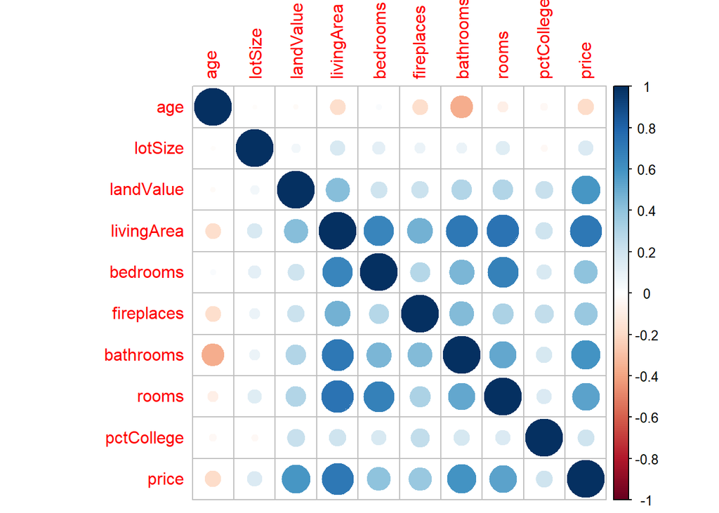

```r
internal_chars <- c('age', 'lotSize', 'landValue', 'livingArea', 'bedrooms', 'fireplaces', 'bathrooms', 'rooms', 'pctCollege', 'price')
corrplot(cor(saratoga[, internal_chars]))
```

Price has the strongest correlation with livingArea. We further analyse the relation between the variables using a scatterplot. As we can see there is a linear positive correlation with many outliers.

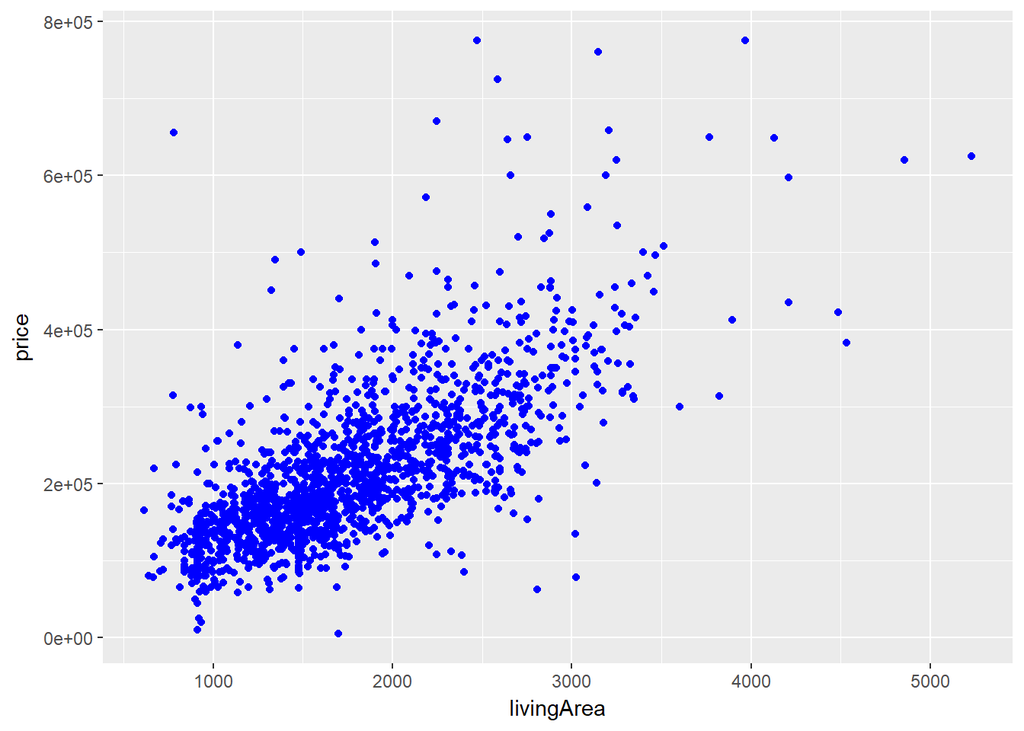

```r
ggplot(aes(x=livingArea, y=price), data=saratoga) + geom_point(color='blue')
```

## Visualise Without the Outliers (exclude houses >3000 sq feet).

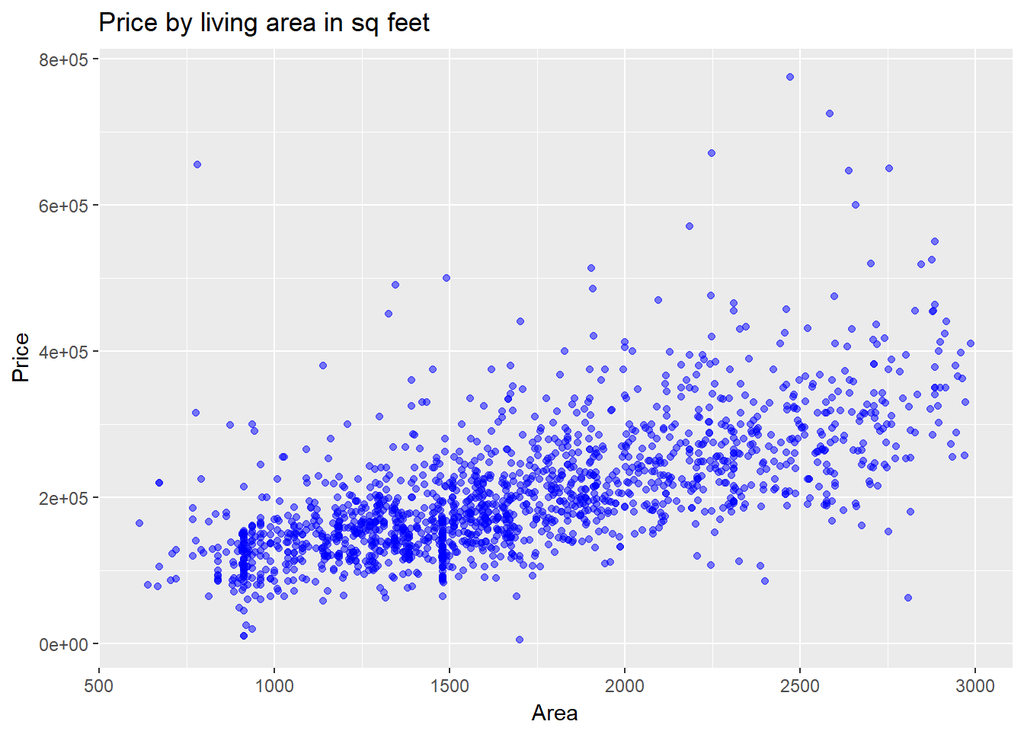

```r
saratoga %>%
        filter(livingArea < 3000) %>%
        ggplot(aes(x=livingArea, y=price)) +
        geom_point(color='blue', alpha=0.5) +
        labs(x='Area', y='Price', title='Price by living area in sq feet')
```

## Analyse Rooms

Strong positive correlations between rooms, bathrooms, bedrooms (expected).

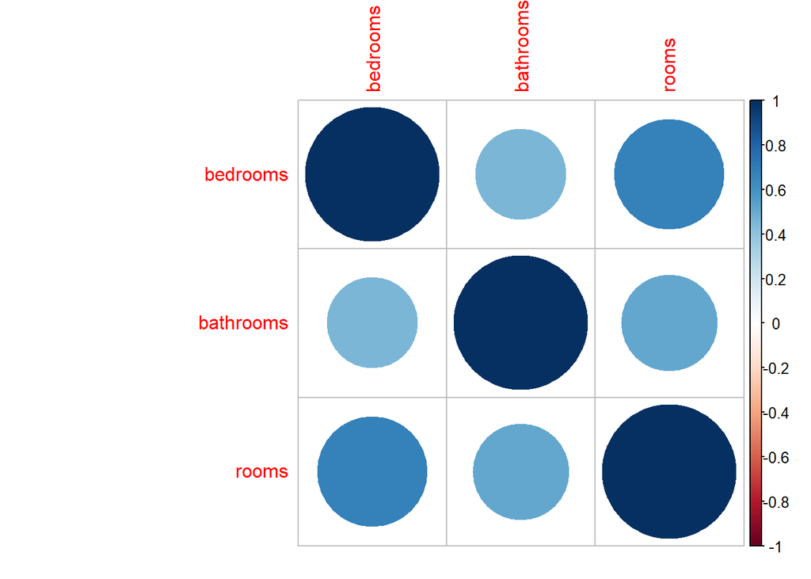

```r
rooms <- c('bedrooms', 'bathrooms', 'rooms')
corrplot(cor(saratoga[, rooms]))
```

## Room Distribution

The majority of the houses have 7 rooms or less.

```r
table(saratoga$rooms)
```

```
##
##   2   3   4   5   6   7   8   9  10  11  12
##   2  80 181 223 247 305 258 142 141  72  77
```

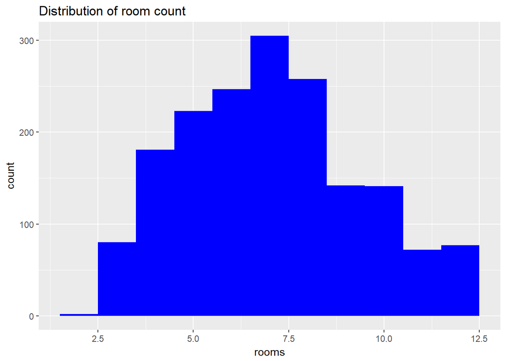

```r
ggplot(aes(x=rooms), data=saratoga) +
        geom_histogram(fill='blue', bins=15, binwidth = 1) +
        ggtitle('Distribution of room count')
```

## Age Distribution

There are 83 observations with age zero and many outliers with only one house attached. The distribution has positive skewness and the extreme majority of houses are below 50 years old.

```r
table(saratoga$age)
```

```
##
##   0   1   2   3   4   5   6   7   8   9  10  11  12  13  14  15  16  17
##  83  75  17  29  21  16  24  15  17  30  36  34  26  36  49  71  88  67
##  18  19  20  21  22  23  24  25  26  27  28  29  30  31  32  33  34  35
##  88  93  60  40  22  13  10  32  26  26  17  17  26  15  34  39  31  37
##  36  37  38  39  40  41  42  43  44  45  46  47  48  49  50  51  52  53
##  23  20  21  14  14  10   7   8   9   6   4   3   7   4  10   5   8  11
##  54  55  56  57  58  59  61  62  63  64  65  66  67  68  69  70  71  73
##   9   5   4   6   1   2   1   1   2   4   1   2   1   1   1   3   3   4
##  74  75  76  77  78  79  80  82  83  84  85  86  88  90  91  93  94  95
##   2   2   1   5   2   1   2   3   4   5   7   1   2   1   1   2   2   4
##  96  98  99 102 103 104 105 106 110 113 114 115 116 118 121 123 124 125
##   1   1   1   2   6   3   4   2   1   2   1   5   3   1   4   4   4   3
## 126 128 129 130 133 134 135 137 138 139 140 142 144 145 149 150 152 153
##   3   1   2   2   2   2   3   1   1   1   1   1   1   1   1   1   1   2
## 154 155 164 165 169 174 176 178 201 225
##   2   1   1   1   1   1   1   1   1   1
```

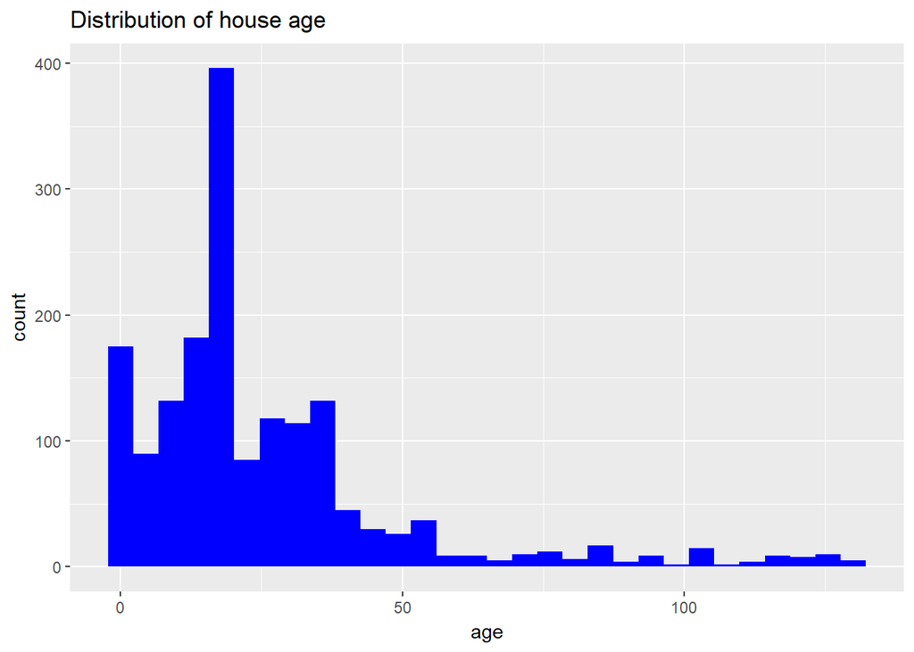

```r
saratoga %>%
        filter(age <= 130) %>%
        ggplot(aes(x=age)) +
        geom_histogram(fill='blue') +
        ggtitle('Distribution of house age')
```

## Checking the Relation Between Price and Age

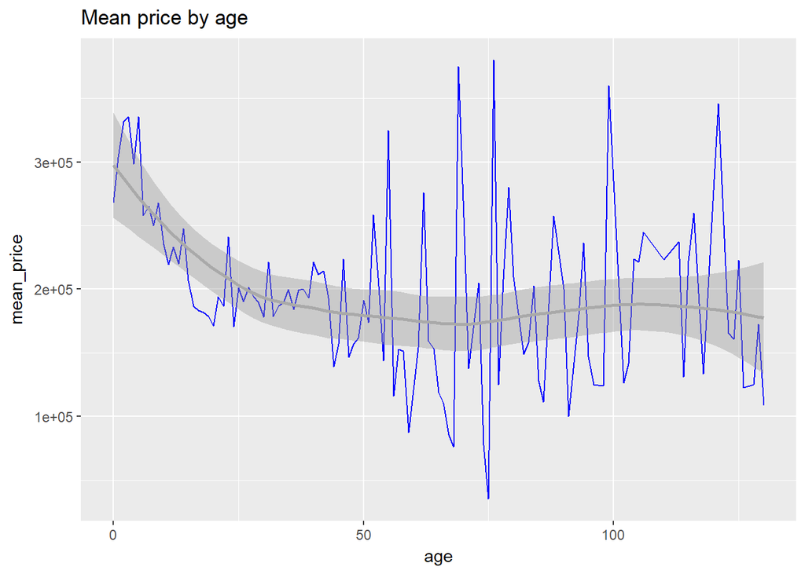

```r
saratoga %>%
        filter(age <= 130) %>%
        group_by(age) %>%
        summarize(mean_price=mean(price)) %>%
        ggplot(aes(x=age, y=mean_price)) +
        geom_line(stat='identity', color='blue') +
        geom_smooth(color='darkgrey') +
        ggtitle('Mean price by age')
```

## Analyse the prices

To check the normality to the distributions of the variables we check the histograms.

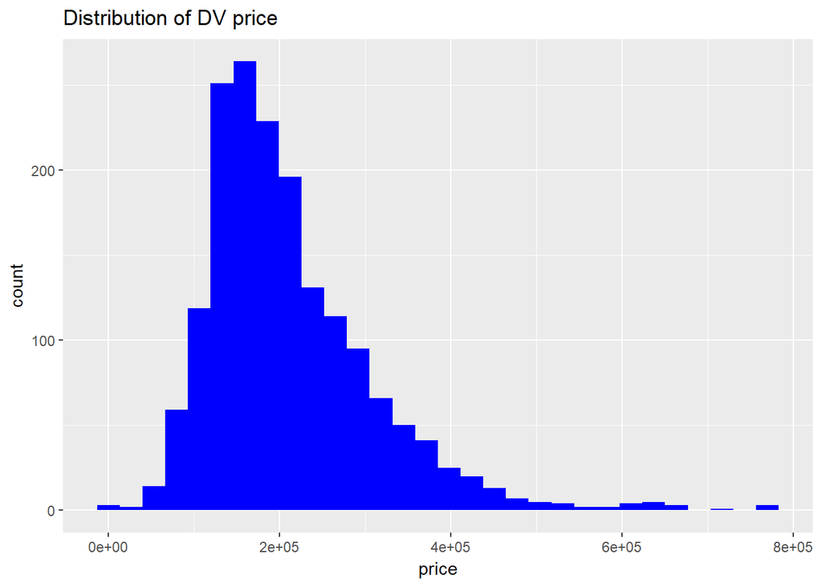

```r
#price
saratoga %>%
        ggplot(aes(x=price)) +
        geom_histogram(fill='blue') +
        ggtitle('Distribution of DV price')
```

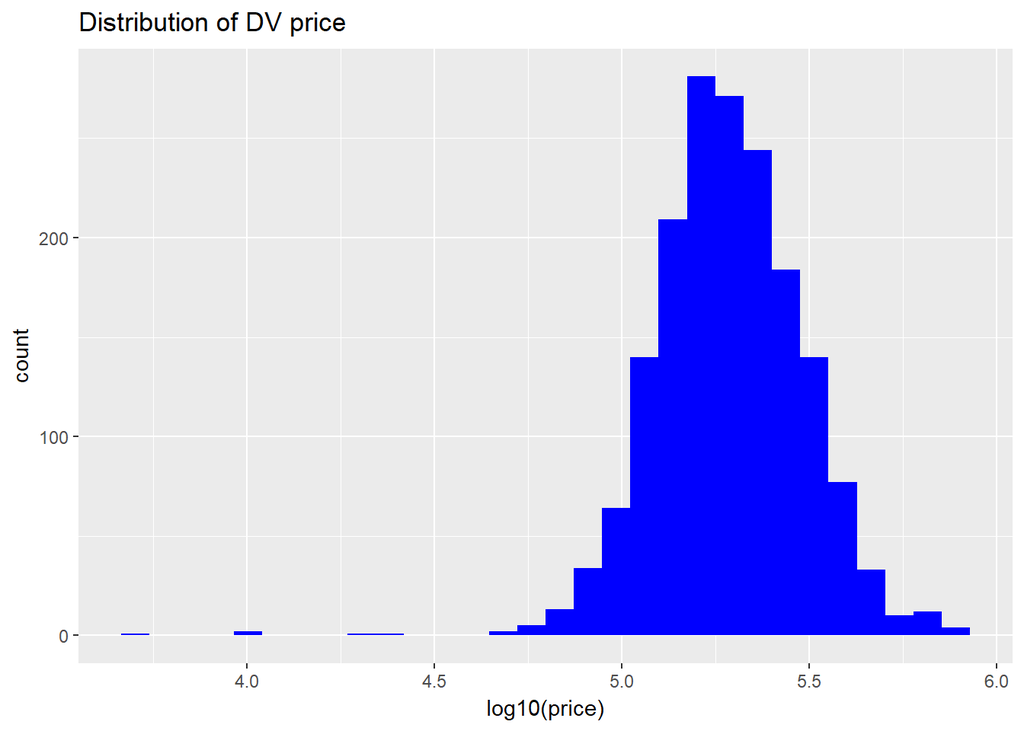

```r
#price log10
saratoga %>%
        ggplot(aes(x=log10(price))) +
        geom_histogram(fill='blue') +
        ggtitle('Distribution of DV price')
```

## Multi Histograms

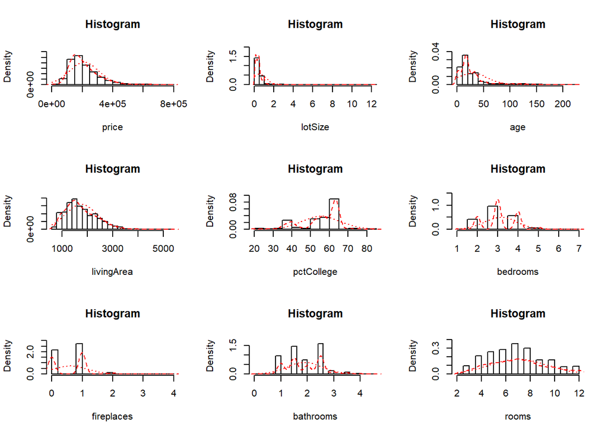

```r
#non-normalized
saratoga %>%
        select(price, lotSize, age, livingArea, pctCollege,bedrooms,
               fireplaces, bathrooms, rooms) %>%
        multi.hist(density=TRUE, dcol="red", main = "Histogram")
```

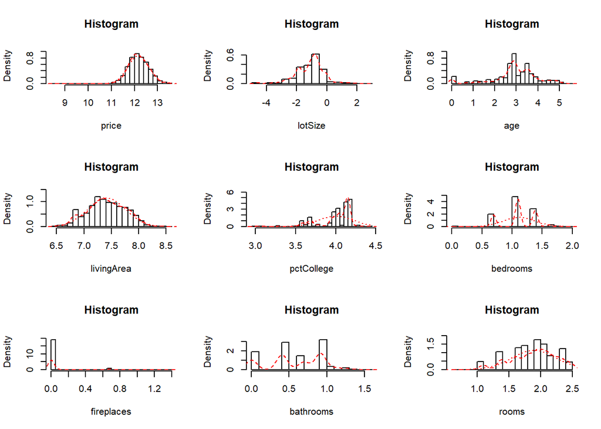

```r
#normalized histograms
saratoga %>%
        select(price, lotSize, age, livingArea, pctCollege,bedrooms,
               fireplaces, bathrooms, rooms) %>%
        sapply(log) %>%
        multi.hist(density=TRUE, dcol="red", main = "Histogram")
```

## Analysis of Variance (ANOVA)

```r
anova1 <- aov(saratoga$price ~ saratoga$sewer)
anova1
```

```
## Call:
##    aov(formula = saratoga$price ~ saratoga$sewer)
##
## Terms:
##                 saratoga$sewer    Residuals
## Sum of Squares    1.110097e+11 1.662484e+13
## Deg. of Freedom              2         1725
##
## Residual standard error: 98171.23
## Estimated effects may be unbalanced
```

```r
TukeyHSD(anova1)
```

```
##   Tukey multiple comparisons of means
##     95% family-wise confidence level
##
## Fit: aov(formula = saratoga$price ~ saratoga$sewer)
##
## $`saratoga$sewer`
##                               diff        lwr       upr     p adj
## public/commercial-none   -34526.71 -101331.74 32278.313 0.4459828
## septic-none              -50668.51 -117933.82 16596.790 0.1810968
## septic-public/commercial -16141.80  -28354.35 -3929.252 0.0055707
```

```r
anova2 <- aov(saratoga$price ~ saratoga$fuel)
anova2
```

```
## Call:
##    aov(formula = saratoga$price ~ saratoga$fuel)
##
## Terms:
##                 saratoga$fuel    Residuals
## Sum of Squares   1.141872e+12 1.559398e+13
## Deg. of Freedom             2         1725
##
## Residual standard error: 95078.85
## Estimated effects may be unbalanced
```

```r
TukeyHSD(anova2)
```

```
##   Tukey multiple comparisons of means
##     95% family-wise confidence level
##
## Fit: aov(formula = saratoga$price ~ saratoga$fuel)
##
## $`saratoga$fuel`
##                   diff        lwr       upr     p adj
## gas-electric  63597.52  49474.248  77720.80 0.0000000
## oil-electric  23796.83   4094.076  43499.58 0.0129411
## oil-gas      -39800.69 -56288.350 -23313.03 0.0000001
```

```r
anova3 <- aov(saratoga$price ~ saratoga$heating)
anova3
```

```
## Call:
##    aov(formula = saratoga$price ~ saratoga$heating)
##
## Terms:
##                 saratoga$heating    Residuals
## Sum of Squares      9.993958e+11 1.573646e+13
## Deg. of Freedom                2         1725
##
## Residual standard error: 95512.21
## Estimated effects may be unbalanced
```

```r
TukeyHSD(anova3)
```

```
##   Tukey multiple comparisons of means
##     95% family-wise confidence level
##
## Fit: aov(formula = saratoga$price ~ saratoga$heating)
##
## $`saratoga$heating`
##                               diff       lwr       upr     p adj
## hot air-electric          64466.80  49997.62 78935.978 0.0000000
## hot water/steam-electric  47243.83  29056.13 65431.533 0.0000000
## hot water/steam-hot air  -17222.97 -31748.53 -2697.403 0.0151128
```

## T-tests for binary variables

```r
#waterfront
waterNo <- saratoga %>%
        select(price, waterfront) %>%
        filter(waterfront == "No")
waterYes <- saratoga %>%
        select(price, waterfront) %>%
        filter(waterfront == "Yes")
t.test(waterNo$price, waterYes$price, alternative = "two.sided")
```

```
##
##  Welch Two Sample t-test
##
## data:  waterNo$price and waterYes$price
## t = -4.0761, df = 14.096, p-value = 0.001119
## alternative hypothesis: true difference in means is not equal to 0
## 95 percent confidence interval:
##  -249391.50  -77495.99
## sample estimates:
## mean of x mean of y
##  210547.9  373991.7
```

```r
#newConstruction
constNo <- saratoga %>%
        select(price, newConstruction) %>%
        filter(newConstruction == "No")
constYes <- saratoga %>%
        select(price, newConstruction) %>%
        filter(newConstruction == "Yes")
t.test(constNo$price, constYes$price, alternative = "two.sided")
```

```
##
##  Welch Two Sample t-test
##
## data:  constNo$price and constYes$price
## t = -7.6638, df = 91.034, p-value = 1.888e-11
## alternative hypothesis: true difference in means is not equal to 0
## 95 percent confidence interval:
##  -92927.39 -54671.53
## sample estimates:
## mean of x mean of y
##  208507.4  282306.8
```

```r
#centralAir
centNo <- saratoga %>%
        select(price, centralAir) %>%
        filter(centralAir == "No")
centYes <- saratoga %>%
        select(price, centralAir) %>%
        filter(centralAir == "Yes")
t.test(centNo$price, centYes$price, alternative = "two.sided")
```

```
##
##  Welch Two Sample t-test
##
## data:  centNo$price and centYes$price
## t = -13.32, df = 987.11, p-value < 2.2e-16
## alternative hypothesis: true difference in means is not equal to 0
## 95 percent confidence interval:
##  -77883.00 -57881.43
## sample estimates:
## mean of x mean of y
##  187021.6  254903.8
```

# Split the set into train and test

```r
set.seed(2017)
train.size <- 0.8
train.index <- sample.int(length(saratoga$price), round(length(saratoga$price) * train.size))
train <- saratoga[train.index,]
test <- saratoga[-train.index,]
```

## OLS Linear Regression

```r
#log transform
#train$price <- log(train$price + 1)
#train$lotSize <- log(train$lotSize + 1)
#train$livingArea <- log(train$livingArea + 1)
#train$rooms <- log(train$rooms + 1)
#train$age <- log(train$age + 1)

#Linear regression model
##R^2 = 0.6607 before log
##R^2 = 0.5927 after log
model <- lm(price~lotSize+age+landValue+livingArea+pctCollege+
                        bedrooms+fireplaces+bathrooms+rooms+heating+fuel+
                        sewer+waterfront+newConstruction+centralAir, data = train)

summary(model)
```

```
##
## Call:
## lm(formula = price ~ lotSize + age + landValue + livingArea +
##     pctCollege + bedrooms + fireplaces + bathrooms + rooms +
##     heating + fuel + sewer + waterfront + newConstruction + centralAir,
##     data = train)
##
## Residuals:
##     Min      1Q  Median      3Q     Max
## -227328  -35329   -3542   28421  403838
##
## Coefficients:
##                          Estimate Std. Error t value Pr(>|t|)
## (Intercept)            -2.275e+04  2.227e+04  -1.022  0.30699
## lotSize                 7.957e+03  2.429e+03   3.276  0.00108 **
## age                    -1.181e+02  6.290e+01  -1.877  0.06072 .
## landValue               8.368e-01  5.154e-02  16.237  < 2e-16 ***
## livingArea              7.300e+01  5.065e+00  14.413  < 2e-16 ***
## pctCollege              3.651e+01  1.674e+02   0.218  0.82734
## bedrooms               -7.117e+03  2.850e+03  -2.497  0.01265 *
## fireplaces              6.334e+02  3.266e+03   0.194  0.84626
## bathrooms               2.117e+04  3.659e+03   5.786 8.91e-09 ***
## rooms                   2.997e+03  1.062e+03   2.823  0.00483 **
## heatinghot air          3.975e+03  1.432e+04   0.278  0.78133
## heatinghot water/steam -7.760e+03  1.491e+04  -0.521  0.60277
## fuelgas                 8.905e+03  1.415e+04   0.629  0.52932
## fueloil                 2.373e+03  1.484e+04   0.160  0.87300
## sewerpublic/commercial  2.424e+04  1.933e+04   1.254  0.21011
## sewerseptic             2.784e+04  1.941e+04   1.434  0.15173
## waterfrontYes           1.142e+05  1.863e+04   6.131 1.14e-09 ***
## newConstructionYes     -3.973e+04  7.975e+03  -4.982 7.10e-07 ***
## centralAirYes           9.581e+03  3.858e+03   2.483  0.01313 *
## ---
## Signif. codes:  0 '***' 0.001 '**' 0.01 '*' 0.05 '.' 0.1 ' ' 1
##
## Residual standard error: 57070 on 1363 degrees of freedom
## Multiple R-squared:  0.6607, Adjusted R-squared:  0.6562
## F-statistic: 147.4 on 18 and 1363 DF,  p-value: < 2.2e-16
```

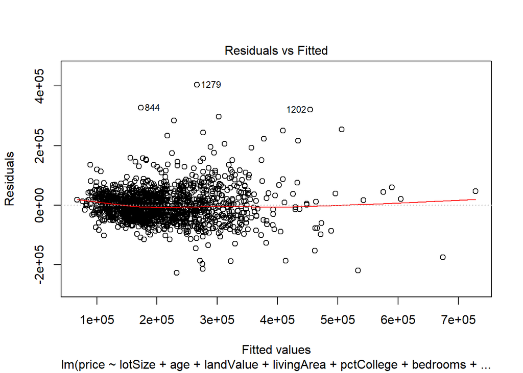

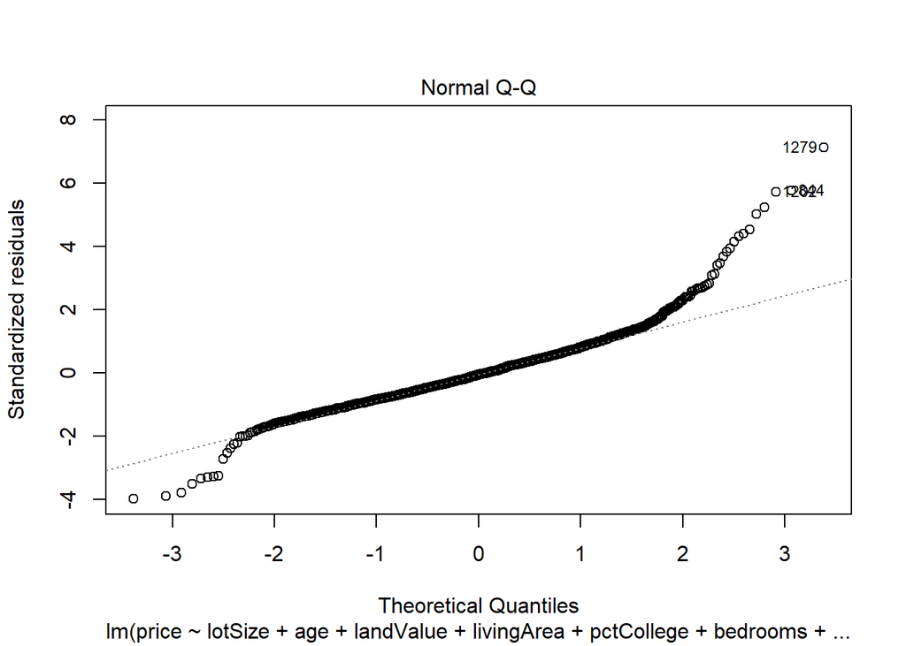

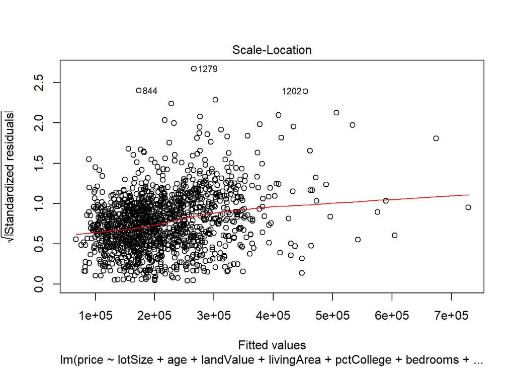

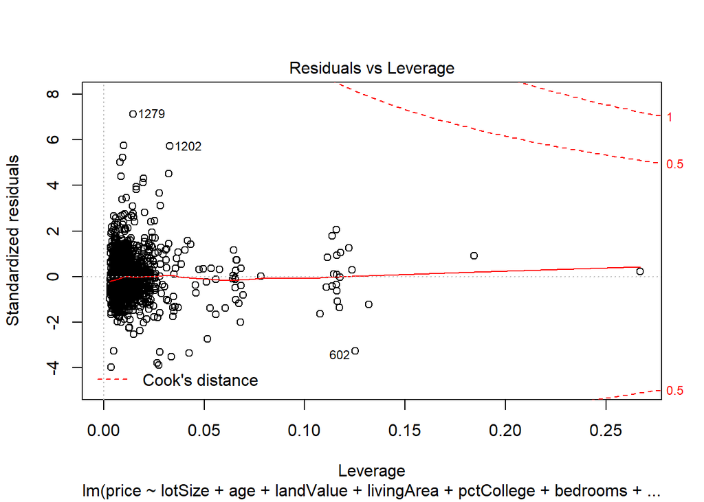

```r
#Residual plots
plot(model)
```

## Prediction

```r
train$pred.price <- predict(model, newdata = train, select =
                                    c(price,lotSize,age,landValue,livingArea,
                                        bedrooms,fireplaces+bathrooms,rooms,heating+fuel+
                                        sewer+waterfront,newConstruction,centralAir))
test$pred.price <- predict(model, newdata = test, select =
                                    c(price,lotSize,age,landValue,livingArea,
                                      bedrooms,fireplaces+bathrooms,rooms,heating+fuel+
                                      sewer+waterfront,newConstruction,centralAir))

#train set
train.corr <- round(cor(train$pred.price, train$price), 2)
train.RMSE <- round(sqrt(mean((train$pred.price - train$price)^2)))
train.MAE <- round(mean(abs(train$pred.price - train$price)))
c(train.corr^2, train.RMSE, train.MAE)
```

```
## [1]     0.6561 56675.0000 40911.0000
```

```r
#test set
test.corr <- round(cor(test$pred.price, test$price), 2)
test.RMSE <- round(sqrt(mean((test$pred.price - test$price)^2)))
test.MAE <- round(mean(abs(test$pred.price - test$price)))
c(test.corr^2, test.RMSE, test.MAE)
```

```
## [1]     0.6241 63329.0000 41732.0000
```

## Cutoff of extreme values using Cooks distance

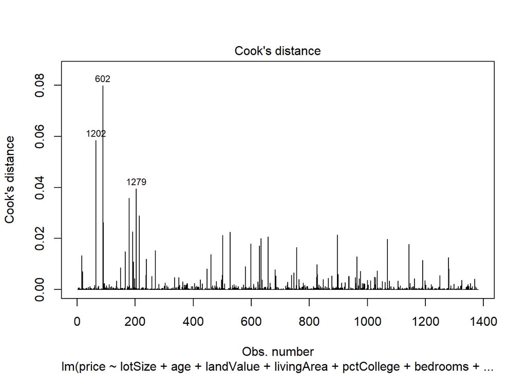

```r
cutoff <- 4/((nrow(train)-length(model$coefficients)-2)) #D plot 4/(n-k-1)
plot(model, which = 4, cook.levels = cutoff) #D values > cutoff
```

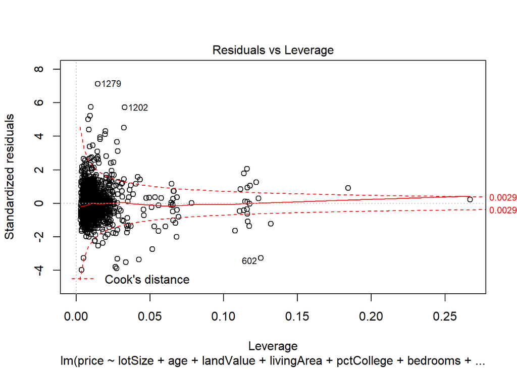

```r
plot(model, which = 5, cook.levels = cutoff)
```

```r
train <- train[-which(rownames(train)
                      %in% c("602", "1202", "1279")),]
```

## Refit the model

```r
model <- lm(price~lotSize+age+landValue+livingArea+pctCollege+
                    bedrooms+fireplaces+bathrooms+rooms+heating+fuel+
                    sewer+waterfront+newConstruction+centralAir, data = train)

summary(model)
```

```
##
## Call:
## lm(formula = price ~ lotSize + age + landValue + livingArea +
##     pctCollege + bedrooms + fireplaces + bathrooms + rooms +
##     heating + fuel + sewer + waterfront + newConstruction + centralAir,
##     data = train)
##
## Residuals:
##     Min      1Q  Median      3Q     Max
## -226956  -34790   -3405   28832  326344
##
## Coefficients:
##                          Estimate Std. Error t value Pr(>|t|)
## (Intercept)            -2.064e+04  2.151e+04  -0.960 0.337417
## lotSize                 8.305e+03  2.347e+03   3.539 0.000415 ***
## age                    -1.690e+02  6.099e+01  -2.771 0.005670 **
## landValue               8.456e-01  5.003e-02  16.901  < 2e-16 ***
## livingArea              7.189e+01  4.902e+00  14.665  < 2e-16 ***
## pctCollege              5.512e+01  1.617e+02   0.341 0.733297
## bedrooms               -7.768e+03  2.757e+03  -2.818 0.004901 **
## fireplaces             -1.966e+03  3.201e+03  -0.614 0.539125
## bathrooms               2.100e+04  3.535e+03   5.939 3.63e-09 ***
## rooms                   3.304e+03  1.026e+03   3.219 0.001317 **
## heatinghot air          4.708e+03  1.383e+04   0.340 0.733640
## heatinghot water/steam -7.214e+03  1.440e+04  -0.501 0.616596
## fuelgas                 8.927e+03  1.367e+04   0.653 0.513866
## fueloil                 2.754e+03  1.434e+04   0.192 0.847732
## sewerpublic/commercial  2.440e+04  1.867e+04   1.307 0.191546
## sewerseptic             2.846e+04  1.875e+04   1.518 0.129285
## waterfrontYes           1.345e+05  1.885e+04   7.138 1.54e-12 ***
## newConstructionYes     -3.993e+04  7.714e+03  -5.176 2.61e-07 ***
## centralAirYes           9.840e+03  3.727e+03   2.640 0.008379 **
## ---
## Signif. codes:  0 '***' 0.001 '**' 0.01 '*' 0.05 '.' 0.1 ' ' 1
##
## Residual standard error: 55130 on 1360 degrees of freedom
## Multiple R-squared:  0.6686, Adjusted R-squared:  0.6642
## F-statistic: 152.4 on 18 and 1360 DF,  p-value: < 2.2e-16
```